# Homework 6

Chris Boyd

3/9/2019

```r
library(tidyverse)
library(dplyr)
library(mosaicData)
```

# Exercise 1

> What variables are in this data set?

The variables are: outcome, smoker, age

> How many observations are there and what does each represent?

There are 1,314 observations. Each observation represents a woman who has been classified as a smoker or non-smoker, with a status of dead or alive 20 years after the original survey.

> Create a table (use the R code below as a guide) and a visualization of the relationship between smoking status and outcome, ignoring age. What do you see? Does it make sense?

```r
Whickham %>%
  count(outcome, smoker)
```

```
## # A tibble: 4 x 3
##   outcome smoker     n
##   <fct>   <fct>  <int>
## 1 Alive   No       502
## 2 Alive   Yes      443
## 3 Dead    No       230
## 4 Dead    Yes      139
```

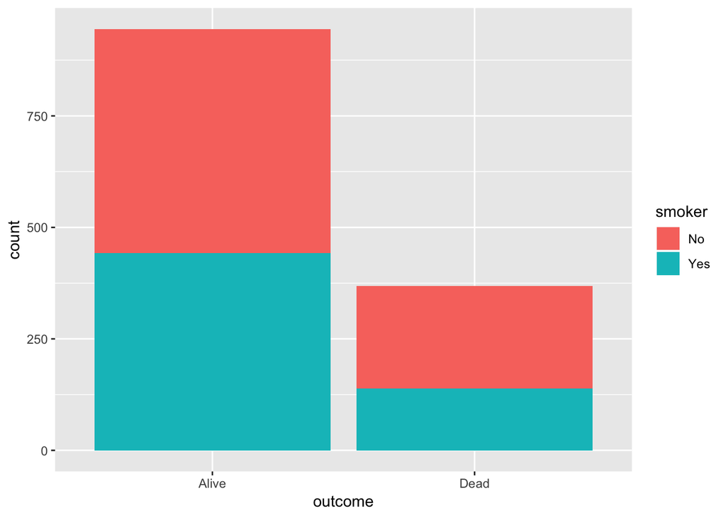

```r
Whickham %>%
  ggplot() +
    geom_bar(mapping = aes(x=outcome, fill=smoker))
```

The data doesnt make sense. It looks like there are more dead non-smokers than dead smokers. I would expect the inverse. Same goes for alive smokers/non-smokers.

> Recode the age variable into an ordered factor with three categories: age <= 44, age > 44 & age <= 64, and age > 64. Now, recreate visualization from above, but facet on your new age factor. What do you see? Does it make sense?

```r
Whickham <- Whickham %>%
  mutate(age_fct = case_when(age >= 0 & age < 40 ~ '< 40',
                               age >= 40 & age < 60 ~ 'between 40 and 60',
                               age >= 60 ~ '> 60'))
Whickham <- Whickham %>% mutate(age_fct = factor(age_fct, ordered=TRUE))
Whickham <- Whickham %>% mutate(age_fct = fct_relevel(age_fct, '< 40', 'between 40 and 60', '>60'))
```

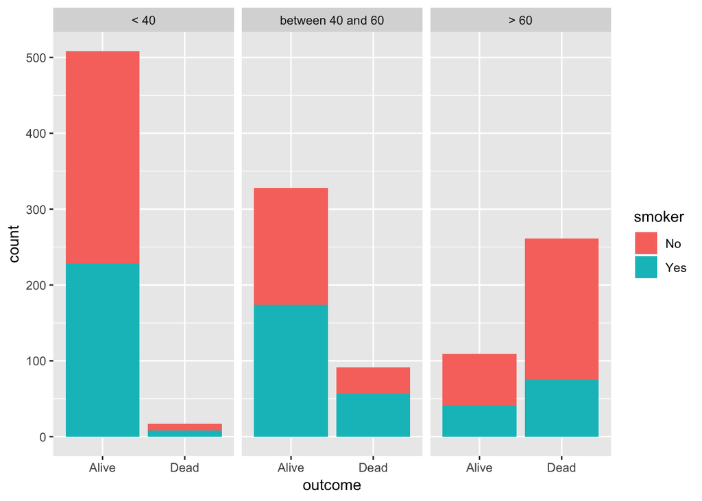

```r
Whickham %>%
  ggplot() +
    geom_bar(mapping = aes(x=outcome, fill=smoker)) +
    facet_wrap(~ age_fct)
```

# Exercise 2

> The Central Limit Theorem states that the sampling distribution of sample means is approximately Normal, regardless of the distribution of your population. For this exercise our population distribution will be a Gamma(1,2) distribution, and we’ll show that the sampling distribution of the mean is in fact normally distributed.

> Generate a random sample of size n = 10000 from a gamma(1,2) distribution and plot a histogram or density curve. Use the code below to help you get your sample.

```r
n <- 10000

gamma_samp <- tibble(x = rgamma(n, shape = 1, scale = 2))

gamma_samp %>%
  summarise(
    mean(x, na.rm=TRUE),
    sd(x, na.rm=TRUE)
  )
```

```
## # A tibble: 1 x 2
##   `mean(x, na.rm = TRUE)` `sd(x, na.rm = TRUE)`
##                     <dbl>                 <dbl>
## 1                    1.99                  1.98
```

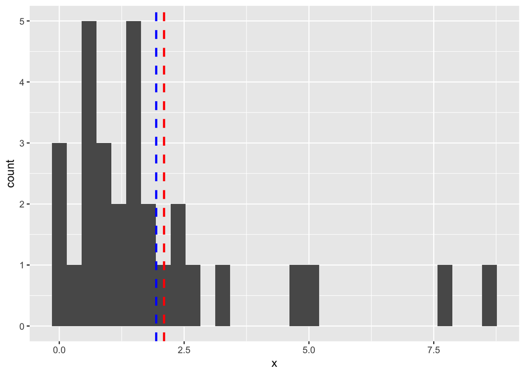

```r
sample_size <- 30
gamma_samp <- tibble(x = rgamma(sample_size, shape = 1, scale = 2))


gamma_samp %>%
  ggplot() +
    geom_histogram(aes(x = x)) +
    geom_vline(aes(xintercept=mean(x)),
            color="blue", linetype="dashed", size=1) +
    geom_vline(aes(xintercept=sd(x)),
            color="red", linetype="dashed", size=1)
```

> Take a sample of size n = 30, again from the Gamma(1,2) distribution, calculate the mean, and assign it to a vector named mean_samp. Repeat this 10000 times!!!! The code below might help.

```r
sample_size <- 30
mean_samp <- rep(NA, 10000)

# start a loop
for(i in 1:10000) {
  g_samp <- rgamma(sample_size, shape = 1, scale = 2)
  mean_samp[i] <- mean(g_samp)
}

# Convert vector to a tibble
mean_samp <- tibble(mean_samp)

mean_samp %>%
  summarise(
    mean=mean(mean_samp),
    sd=sd(mean_samp)
  )
```

```
## # A tibble: 1 x 2
##    mean    sd
##   <dbl> <dbl>
## 1  2.00 0.366
```

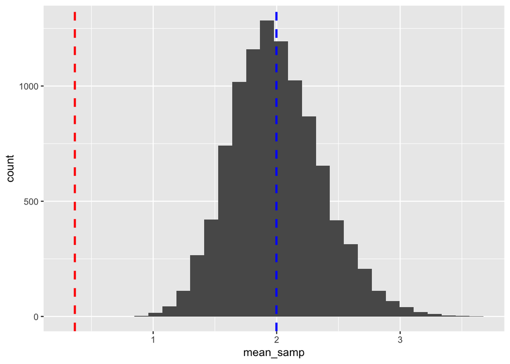

```r
mean_samp %>%
  ggplot() +
    geom_histogram(aes(x = mean_samp)) +
    geom_vline(aes(xintercept=mean(mean_samp)),
            color="blue", linetype="dashed", size=1) +
    geom_vline(aes(xintercept=sd(mean_samp)),
            color="red", linetype="dashed", size=1)
```

> Did anything surprise you about your answers to #6?

I’m suprised the SD is so small.

```r
sample_size <- 300
mean_samp <- rep(NA, 10000)

# start a loop
for(i in 1:10000) {
  g_samp <- rgamma(sample_size, shape = 1, scale = 2)
  mean_samp[i] <- mean(g_samp)
}

# Convert vector to a tibble
mean_samp <- tibble(mean_samp)

mean_samp %>%
  summarise(
    mean=mean(mean_samp),
    sd=sd(mean_samp)
  )
```

```
## # A tibble: 1 x 2
##    mean    sd
##   <dbl> <dbl>
## 1  2.00 0.116
```

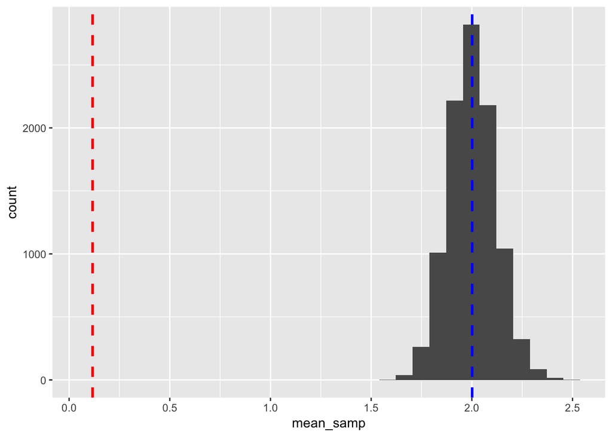

```r
mean_samp %>%
  ggplot() +
    geom_histogram(aes(x = mean_samp)) +
    geom_vline(aes(xintercept=mean(mean_samp)),
            color="blue", linetype="dashed", size=1) +
    geom_vline(aes(xintercept=sd(mean_samp)),
            color="red", linetype="dashed", size=1)
```